# Flow Summary Analysis

# Read in data

Clear environment, add libraries

```r
rm(list = ls())
library(ggplot2)
library(ggrepel)
library(scales)
library(forcats)
library(munsell)
library(ggh4x)
library(wesanderson)
library(jtools)
library(gridExtra)
library(PerformanceAnalytics)
```

Provide info for all runs to be analyzed

```r
# Write in paths for all CSVs to be analyzed
CSVs = c("../MEFL_data/e_coli_8.23.22_all_events.csv","../MEFL_data/p_putida_all_events.csv","../MEFL_data/c_necator_2.9.22_all_events.csv", "../MEFL_data/c_necator_2.10.22_all_events.csv", "../MEFL_data/c_necator_2.11.22_all_events.csv", "../MEFL_data/k_nataicola_2.23.22_all_events.csv", "../MEFL_data/k_nataicola_2.23.22_2_all_events.csv", "../MEFL_data/k_nataicola_2.24.22_all_events.csv", "../MEFL_data/k_nataicola_2.24.22_2_all_events.csv","../MEFL_data/k_nataicola_2.24.22_3_all_events.csv")

# Provide filename to convert sample ID in output to meaningful ID
sample_names = read.csv("../MEFL_data/sample_names.csv", header=TRUE)

# Remove DOE oversampling replicates - some conditions had extra replicates for DOE analysis. To keep the number of samples the same for all conditions, only the first set of replicates for each condition will be analyzed.
sample_names <- sample_names[!(sample_names$well == "H2" | sample_names$well == "B3" | sample_names$well == "D3" | sample_names$well == "E2"),]

# Create a list of the species for each filename in CSVs, then pair them in a df
species_list = c("e_coli", "p_putida", "c_necator", "c_necator", "c_necator", "k_nataicola", "k_nataicola", "k_nataicola", "k_nataicola", "k_nataicola")
species_df <- data.frame(CSVs, species_list)

# Initialize dataframe to be filled in from parsed CSVs
df <- data.frame('promoter' = NA, 'rbs' = NA, 'replicate' = NA, 'run_id' = NA, 'species' = NA, 'MEFL' = NA, 'FSC' = NA, 'SSC' = NA)
```

Read in csv output of FlowCal analysis for all runs, parse and save to a dataframe

```r
for (file in CSVs) {
  temp_df = read.csv(file, header=TRUE)

  # Need to translate "sample" from FlowCal output into promoter + RBS + replicate columns
  # First add promoter and rbs columns from sample_names df
  for (row in 1:nrow(sample_names)) {
    temp_df$promoter[grepl(sample_names$well[row], temp_df$sample, fixed = TRUE)] <- sample_names$promoter[row]
    temp_df$rbs[grepl(sample_names$well[row], temp_df$sample, fixed = TRUE)] <- sample_names$rbs[row]
  }
  # Pull out replicate number from flag -rep
  nrep = 3
  for (rep in 1:nrep){
    temp_df$replicate[grepl(paste(c("-",rep),collapse=""), temp_df$sample, fixed = TRUE)] <- rep
  }
  # Add species
  temp_df$species <- species_df$species_list[grepl(file,species_df$CSVs, fixed = TRUE)]

  # Add parsed data to overall df and remove temp df
  df <- rbind(df,subset(temp_df, select = -sample))
  rm(temp_df)
}

rm(rep,nrep,row,file)
# Remove pesky initial NA row from df
df <- df[complete.cases(df),]
```

Add growth defect information to dataframe

```r
# Make dataframe of samples that have growth defects
defect_spec <- c(rep("c_necator",times=5),rep("k_nataicola",times=7))
defect_pro <- c("J23106","J23103","J23103","J23100","J23100","J23103","J23103","J23103","J23106","J23103","J23106","J23106")
defect_rbs <- c("RiboJ_BCD-2","RiboJ_BCD-2","B0033m","RiboJ_UTR1","RiboJ_BCD-2","B0033m","B0034m","BCD-2","B0033m","B0032m","B0034m","B0032m")
defects <- data.frame(defect_spec,defect_pro,defect_rbs)
rm(defect_spec,defect_pro,defect_rbs)


# Add this info to main dataframe
df$growth_defect <- "no"
for (i in 1:length(defects$defect_pro)) {
        df$growth_defect[df$species == defects$defect_spec[i] & df$promoter == defects$defect_pro[i] & df$rbs == defects$defect_rbs[i]] <- "yes"
}
rm(i)
```

Set factors as factors

```r
df$promoter <- as.factor(df$promoter)
df$rbs <- as.factor(df$rbs)
df$replicate <- as.factor(df$replicate)
df$run_id <- as.factor(df$run_id)
df$species <- as.factor(df$species)
```

Add column for MEFL with average empty vector MEFL subtracted, per run

```r
for (run in unique(df$run_id)){
  mean_autofluorescence = mean(subset(df, run_id==run & promoter=='empty_vector')$MEFL)
  df$MEFL_no_auto <- df$MEFL - mean_autofluorescence
  rm(mean_autofluorescence)
}
rm(run)
```

# Violin plots

Make violin plots

```r
# Make species lookup list
spec.labs = c("e_coli" = "E. coli", "p_putida" = "P.putida", "c_necator" = "C. necator", "k_nataicola" = "K. nataicola")

# Define plot settings
for (specie in unique(df$species)){
  # Define starting data
  p <- ggplot(data=subset(df,replicate==1 & species == specie), aes(x=rbs, y=MEFL))

  # Format axes
  p <- p + xlab(" ") + ylab("Fluorescence, MEFL") + theme(axis.text.x = element_text(angle = 90, vjust = 0.5, hjust=1))
  p <- p + scale_y_log10(breaks = trans_breaks("log10", function(x) 10^x), labels = trans_format("log10", math_format(10^.x)), limits = c(10**-0.75,10**6.5))

  # + ggtitle(paste("Fluorescent intensity", spec.labs[specie]))

  # Assign color to replicate 1
  base_color <- "5B 5/6"
  p <- p + geom_violin(colour=mnsl(base_color), fill=mnsl(lighter(base_color, 2)), outlier.colour="transparent")

  # Add replicates 2 and 3
  p <- p + geom_violin(data = subset(df,replicate==2 & species == specie),colour = mnsl(rygbp(base_color, 2)),fill=mnsl(lighter(rygbp(base_color, 2),2)), outlier.colour="transparent")
  p <- p + geom_violin(data = subset(df,replicate==3 & species == specie),colour = mnsl(pbgyr(base_color, 2)),fill=mnsl(lighter(pbgyr(base_color, 2),2)), outlier.colour="transparent")

  # Facet labels
  pro.labs <- c("Empty", "J23103", "J23106", "J23100")
  names(pro.labs) <- c("empty_vector","J23103","J23106","J23100")

  # Make facets
  p <- p  +  facet_grid2(~fct_relevel(promoter,"empty_vector","J23103","J23106","J23100"),labeller = as_labeller(pro.labs), scales = "free", space = "free", strip = strip_vanilla(clip = "off",size = "variable"))

  # Display Plot
  #p
  # Save plot
  setwd("../outputs")
  ggsave(paste(c(specie,"violins.pdf"),collapse="_"), p, device = "pdf", width = 7, height = 5, units ="in")
}
```

# Lookup tables

Make summary / lookup table of positive and negative numbers

```r
# Make new dataframe containing arithmetic mean of each promoter/rbs pair, pooling replicates
df_summary = setNames(data.frame(matrix(ncol = 6, nrow = 0)), c("mean","std_err", "species","rbs","promoter","growth_defect"))

for (specie in unique(df$species)) {
  for (pro in unique(df$promoter[! df$promoter %in% "empty_vector"])) {
      for (rb in unique(df$rbs[! df$rbs %in% "empty_vector"])) {
        df_summary_row <- cbind(data.frame("mean" = mean(subset(df,df$species==specie & df$promoter==pro & df$rbs ==rb)$MEFL)), data.frame("std_err" = sd(subset(df,df$species==specie & df$promoter==pro & df$rbs ==rb)$MEFL)/sqrt(length(subset(df,df$species==specie & df$promoter==pro & df$rbs ==rb)$MEFL))), data.frame("species" = specie), data.frame("rbs" = rb), data.frame("promoter" = pro), data.frame("growth_defect" = unique(df$growth_defect[df$species==specie & df$promoter==pro & df$rbs==rb])))
        df_summary = rbind(df_summary,df_summary_row)
      }
  }
}

rm(df_summary_row)

df_summary$species <- as.factor(df_summary$species)
df_summary$growth_defect <- as.factor(df_summary$growth_defect)

write.csv(df_summary,"../outputs/mean_summary.csv",row.names = FALSE)
```

Make plots of arithmetic mean

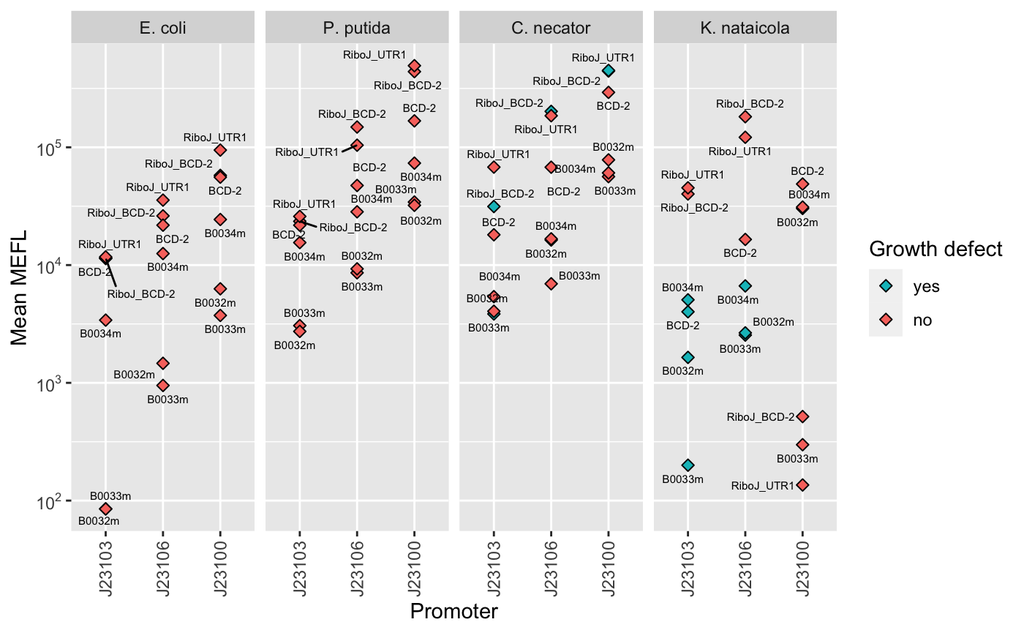

```r
# Put in data
p <- ggplot(df_summary, aes(x=fct_relevel(promoter, "J23103", "J23106", "J23100"), y=mean, label = rbs, fill = growth_defect))

# Labeling stuff
spec.labs <- c("E. coli", "P. putida", "C. necator", "K. nataicola")
names(spec.labs) <- c("e_coli", "p_putida", "c_necator", "k_nataicola")

# Add formatting
p <- p + scale_y_log10(breaks = trans_breaks("log10", function(x) 10^x),
              labels = trans_format("log10", math_format(10^.x))) + geom_point(size=2, shape=23) + facet_wrap(~fct_relevel(species,"e_coli","p_putida","c_necator","k_nataicola"), ncol=4, labeller = as_labeller(spec.labs)) + geom_text_repel(size=2) + xlab("Promoter") + ylab("Mean MEFL") + guides(fill = guide_legend(title = "Growth defect", reverse = TRUE)) + theme(axis.text.x = element_text(angle = 90, vjust = 0.5, hjust=1))

# Save and display plot
ggsave(filename="../outputs/arithmetic_mean_LUT.pdf")
p
```

Make separate dataframe for positive values of MEFL only (negative values result from conversion of voltage -> AU -> MEFL). This will be used for geomeric mean and log calculations

```r
# Pull out a new df of only positive values
pos_df <- subset(df, df$MEFL > 0)

# Number of rows deleted
print("Number of observations omitted due to negative MEFL values")
```

```
[1] "Number of observations omitted due to negative MEFL values"
```

```r
length(df$MEFL) - length(pos_df$MEFL)
```

```
[1] 343887
```

Make summary / lookup table of positive numbers only

```r
# Make new dataframe containing geometric mean of each promoter/rbs pair, pooling replicates
pos_df_summary = setNames(data.frame(matrix(ncol = 7, nrow = 0)), c("mean","std_err","gmean", "species","rbs","promoter","growth_defect"))

for (specie in unique(pos_df$species)) {
  for (pro in unique(pos_df$promoter[! pos_df$promoter %in% "empty_vector"])) {
      for (rb in unique(pos_df$rbs[! pos_df$rbs %in% "empty_vector"])) {
        pos_df_summary_row <- cbind(data.frame("mean" = mean(subset(pos_df,pos_df$species==specie & pos_df$promoter==pro & pos_df$rbs ==rb)$MEFL)), data.frame("std_err" = sd(subset(pos_df,pos_df$species==specie & pos_df$promoter==pro & pos_df$rbs ==rb)$MEFL)/sqrt(length(subset(pos_df,pos_df$species==specie & pos_df$promoter==pro & pos_df$rbs ==rb)$MEFL))), data.frame("gmean" = exp(mean(log(subset(pos_df,pos_df$species==specie & pos_df$promoter==pro & pos_df$rbs ==rb)$MEFL)))), data.frame("species" = specie), data.frame("rbs" = rb), data.frame("promoter" = pro), data.frame("growth_defect" = unique(pos_df$growth_defect[pos_df$species==specie & pos_df$promoter==pro & pos_df$rbs==rb])))
        pos_df_summary = rbind(pos_df_summary,pos_df_summary_row)
      }
  }
}

rm(pos_df_summary_row)

pos_df_summary$species <- as.factor(pos_df_summary$species)
pos_df_summary$growth_defect <- as.factor(pos_df_summary$growth_defect)

write.csv(pos_df_summary,"../outputs/gmean_summary.csv",row.names = FALSE)
```

# Original CIDAR comparison

Import original CIDAR study values to compare to openCIDAR constructs. These were extraploated from the original CIDAR paper (Iverson et al. 2016) supplemental figure 1

```r
# Import original CIDAR values
og_cidar = read.csv("../MEFL_data/CIDAR_MEFL_values.csv", header=TRUE)
```

Make plot

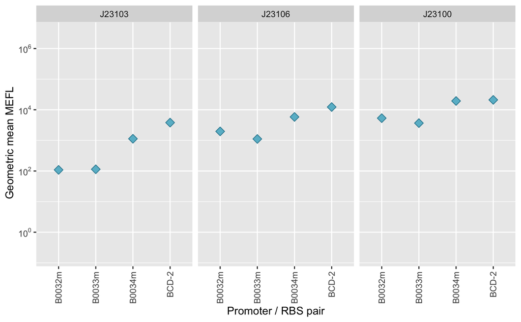

```r
# Put in data
p2 <- ggplot(og_cidar, aes(x=rbs, y=gmean, label = rbs))

# Add formatting
base_color <- "5B 5/6"

p2 <- p2 + scale_y_log10(breaks = trans_breaks("log10", function(x) 10^x), labels = trans_format("log10", math_format(10^.x)), limits = c(10**-0.75,10**6.5)) + geom_point(size=3, shape=23, colour=mnsl(base_color), fill=mnsl(lighter(base_color, 2)), outlier.colour="transparent") + xlab("Promoter / RBS pair") + ylab(" Geometric mean MEFL") + theme(axis.text.x = element_text(angle = 90, vjust = 0.5, hjust=1)) + facet_wrap(~fct_relevel(promoter,"J23103","J23106","J23100"), ncol=3)
# Save and display plot
ggsave(filename="../outputs/og_CIDAR_comparison.pdf")
p2
```

# Rank order plots

Combine promoter / RBS combination together into one variable

```r
# Concatenate promoter and rbs pairs together into blocking variables
df$design <- paste(df$promoter,df$rbs,sep="_")
df$design <- as.factor(df$design)
```

Make rank order plots

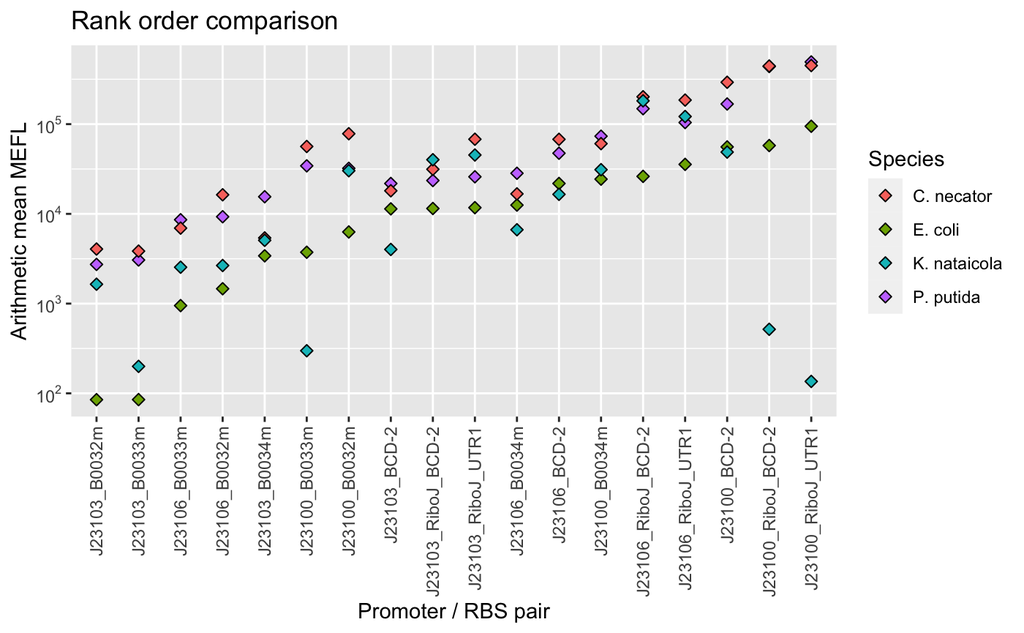

```r
# Add design column to summary row
df_summary$design <- paste(df_summary$promoter,df_summary$rbs,sep="_")
df_summary$design <- as.factor(df_summary$design)

# Make list
ec_sum = subset(df_summary,df_summary$species=="e_coli")
ec_rank_order = reorder(ec_sum$design,ec_sum$mean)

# Put in data
p3 <- ggplot(df_summary, aes(x=fct_relevel(design,levels(ec_rank_order)), y=mean, fill = species))
p5 <- p3 + scale_y_log10(breaks = trans_breaks("log10", function(x) 10^x), labels = trans_format("log10", math_format(10^.x))) + geom_point(size=2, shape=23) + ggtitle("Rank order comparison") + xlab("Promoter / RBS pair") + ylab("Arithmetic mean MEFL") + theme(axis.text.x = element_text(angle = 90, vjust = 0.5, hjust=1)) + scale_fill_discrete(name = "Species", labels = c("C. necator", "E. coli", "K. nataicola", "P. putida"))

ggsave(filename="../outputs/rank_order_comparison.pdf")
p5
```

# Correlation plots

```r
gmean_corr_tb <- data.frame(ec = pos_df_summary$gmean[df_summary$species=="e_coli"], pp = pos_df_summary$gmean[df_summary$species=="p_putida"], cn = pos_df_summary$gmean[df_summary$species=="c_necator"], kn = pos_df_summary$gmean[df_summary$species=="k_nataicola"])
```

Using correlation table package Log-transform data

```r
log_gmean_corr_tb <- data.frame(E.coli = log10(pos_df_summary$gmean[df_summary$species=="e_coli"]), P.putida = log10(pos_df_summary$gmean[df_summary$species=="p_putida"]), C.necator = log10(pos_df_summary$gmean[df_summary$species=="c_necator"]), K.nataicola = log10(pos_df_summary$gmean[df_summary$species=="k_nataicola"]))
```

Plot

```r
# Correlation panel
panel.cor <- function(x, y){
    usr <- par("usr"); on.exit(par(usr))
    par(usr = c(0, 1, 0, 1))
    r <- round(cor(x, y), digits=2)
    txt <- paste0("R = ", r)
    cex.cor <- 0.8/strwidth(txt)
    text(0.5, 0.5, txt, cex = cex.cor * r)
}
# Customize upper panel
upper.panel<-function(x, y){
  points(x,y, pch = 19)
}
# Create the plots
pdf("../outputs/correlation_plot.pdf")
pairs(log_gmean_corr_tb,
      lower.panel = panel.cor,
      upper.panel = upper.panel)
dev.off()
```

# Linear models

Set the empty vector as the reference level

```r
# Make sure "empty_vector" is first level for promoter and rbs
pos_df$rbs <- relevel(pos_df$rbs,"empty_vector")
pos_df$promoter <- relevel(pos_df$promoter,"empty_vector")
```

Build model with interactions

```r
ec_pro_rbs_int_lm <-lm(log10(MEFL) ~ promoter * rbs, data = subset(pos_df, pos_df$species == "e_coli"))
summary(ec_pro_rbs_int_lm)
```

```
Call:
lm(formula = log10(MEFL) ~ promoter * rbs, data = subset(pos_df,
    pos_df$species == "e_coli"))

Residuals:
    Min      1Q  Median      3Q     Max
-5.8770 -0.1085  0.0028  0.1256  3.2969

Coefficients: (9 not defined because of singularities)
                                Estimate Std. Error  t value Pr(>|t|)
(Intercept)                    1.6577277  0.0008225  2015.52   <2e-16 ***
promoterJ23100                 3.2853304  0.0010901  3013.69   <2e-16 ***
promoterJ23103                 2.3820104  0.0010946  2176.07   <2e-16 ***
promoterJ23106                 2.8651999  0.0010944  2618.14   <2e-16 ***
rbsB0032m                     -1.4039493  0.0010228 -1372.60   <2e-16 ***
rbsB0033m                     -1.5885979  0.0010250 -1549.89   <2e-16 ***
rbsB0034m                     -0.4583298  0.0010220  -448.48   <2e-16 ***
rbsBCD-2                      -0.2153382  0.0010216  -210.78   <2e-16 ***
rbsRiboJ_BCD-2                -0.1331466  0.0010240  -130.02   <2e-16 ***
rbsRiboJ_UTR1                         NA         NA       NA       NA
promoterJ23100:rbsB0032m       0.2179934  0.0014423   151.14   <2e-16 ***
promoterJ23103:rbsB0032m      -0.7699685  0.0014620  -526.64   <2e-16 ***
promoterJ23106:rbsB0032m              NA         NA       NA       NA
promoterJ23100:rbsB0033m       0.1678978  0.0014467   116.05   <2e-16 ***
promoterJ23103:rbsB0033m      -0.6815731  0.0014776  -461.28   <2e-16 ***
promoterJ23106:rbsB0033m              NA         NA       NA       NA
promoterJ23100:rbsB0034m      -0.1346069  0.0014432   -93.27   <2e-16 ***
promoterJ23103:rbsB0034m      -0.0849604  0.0014461   -58.75   <2e-16 ***
promoterJ23106:rbsB0034m              NA         NA       NA       NA
promoterJ23100:rbsBCD-2       -0.0202568  0.0014408   -14.06   <2e-16 ***
promoterJ23103:rbsBCD-2        0.2018541  0.0014453   139.66   <2e-16 ***
promoterJ23106:rbsBCD-2               NA         NA       NA       NA
promoterJ23100:rbsRiboJ_BCD-2 -0.0815161  0.0014416   -56.55   <2e-16 ***
promoterJ23103:rbsRiboJ_BCD-2  0.1257739  0.0014473    86.90   <2e-16 ***
promoterJ23106:rbsRiboJ_BCD-2         NA         NA       NA       NA
promoterJ23100:rbsRiboJ_UTR1          NA         NA       NA       NA
promoterJ23103:rbsRiboJ_UTR1          NA         NA       NA       NA
promoterJ23106:rbsRiboJ_UTR1          NA         NA       NA       NA
---
Signif. codes:  0 ‘***’ 0.001 ‘**’ 0.01 ‘*’ 0.05 ‘.’ 0.1 ‘ ’ 1

Residual standard error: 0.2373 on 1996188 degrees of freedom
Multiple R-squared:  0.9406,    Adjusted R-squared:  0.9406
F-statistic: 1.756e+06 on 18 and 1996188 DF,  p-value: < 2.2e-16
```

```r
pp_pro_rbs_int_lm <-lm(log10(MEFL) ~ promoter * rbs, data = subset(pos_df, pos_df$species == "p_putida"))
summary(pp_pro_rbs_int_lm)
```

```
Call:
lm(formula = log10(MEFL) ~ promoter * rbs, data = subset(pos_df,
    pos_df$species == "p_putida"))

Residuals:
    Min      1Q  Median      3Q     Max
-5.6122  0.0807  0.2994  0.5129  3.3538

Coefficients: (9 not defined because of singularities)
                               Estimate Std. Error  t value Pr(>|t|)
(Intercept)                    1.849152   0.003101  596.360  < 2e-16 ***
promoterJ23100                 3.666216   0.004201  872.801  < 2e-16 ***
promoterJ23103                 2.410077   0.004217  571.465  < 2e-16 ***
promoterJ23106                 2.445192   0.004241  576.616  < 2e-16 ***
rbsB0032m                     -0.778356   0.004129 -188.496  < 2e-16 ***
rbsB0033m                     -0.629787   0.004091 -153.942  < 2e-16 ***
rbsB0034m                     -0.398493   0.004103  -97.116  < 2e-16 ***
rbsBCD-2                      -0.177808   0.004096  -43.411  < 2e-16 ***
rbsRiboJ_BCD-2                 0.642929   0.004047  158.850  < 2e-16 ***
rbsRiboJ_UTR1                        NA         NA       NA       NA
promoterJ23100:rbsB0032m      -0.743476   0.005798 -128.232  < 2e-16 ***
promoterJ23103:rbsB0032m      -0.142589   0.005798  -24.595  < 2e-16 ***
promoterJ23106:rbsB0032m             NA         NA       NA       NA
promoterJ23100:rbsB0033m      -0.506989   0.005738  -88.364  < 2e-16 ***
promoterJ23103:rbsB0033m      -0.390569   0.005769  -67.702  < 2e-16 ***
promoterJ23106:rbsB0033m             NA         NA       NA       NA
promoterJ23100:rbsB0034m      -0.763920   0.005754 -132.774  < 2e-16 ***
promoterJ23103:rbsB0034m       0.004092   0.005780    0.708    0.479
promoterJ23106:rbsB0034m             NA         NA       NA       NA
promoterJ23100:rbsBCD-2       -0.575678   0.005735 -100.373  < 2e-16 ***
promoterJ23103:rbsBCD-2       -0.031090   0.005766   -5.392 6.95e-08 ***
promoterJ23106:rbsBCD-2              NA         NA       NA       NA
promoterJ23100:rbsRiboJ_BCD-2 -0.831903   0.005695 -146.084  < 2e-16 ***
promoterJ23103:rbsRiboJ_BCD-2 -0.816113   0.005729 -142.463  < 2e-16 ***
promoterJ23106:rbsRiboJ_BCD-2        NA         NA       NA       NA
promoterJ23100:rbsRiboJ_UTR1         NA         NA       NA       NA
promoterJ23103:rbsRiboJ_UTR1         NA         NA       NA       NA
promoterJ23106:rbsRiboJ_UTR1         NA         NA       NA       NA
---
Signif. codes:  0 ‘***’ 0.001 ‘**’ 0.01 ‘*’ 0.05 ‘.’ 0.1 ‘ ’ 1

Residual standard error: 0.9355 on 1991583 degrees of freedom
Multiple R-squared:  0.4064,    Adjusted R-squared:  0.4064
F-statistic: 7.574e+04 on 18 and 1991583 DF,  p-value: < 2.2e-16
```

```r
cn_pro_rbs_int_lm <-lm(log10(MEFL) ~ promoter * rbs, data = subset(pos_df, pos_df$species == "c_necator"))
summary(cn_pro_rbs_int_lm)
```

```
Call:
lm(formula = log10(MEFL) ~ promoter * rbs, data = subset(pos_df,
    pos_df$species == "c_necator"))

Residuals:
    Min      1Q  Median      3Q     Max
-6.7233 -0.0840  0.0395  0.1692  2.4898

Coefficients: (9 not defined because of singularities)
                               Estimate Std. Error  t value Pr(>|t|)
(Intercept)                    1.806014   0.000798 2263.222   <2e-16 ***
promoterJ23100                 3.692954   0.001491 2477.728   <2e-16 ***
promoterJ23103                 2.988895   0.001493 2002.381   <2e-16 ***
promoterJ23106                 3.360120   0.001508 2227.740   <2e-16 ***
rbsB0032m                     -1.024311   0.001805 -567.421   <2e-16 ***
rbsB0033m                     -2.162381   0.002750 -786.413   <2e-16 ***
rbsB0034m                     -1.000132   0.001787 -559.772   <2e-16 ***
rbsBCD-2                      -0.367273   0.001789 -205.243   <2e-16 ***
rbsRiboJ_BCD-2                 0.091041   0.001791   50.834   <2e-16 ***
rbsRiboJ_UTR1                        NA         NA       NA       NA
promoterJ23100:rbsB0032m       0.277513   0.002552  108.747   <2e-16 ***
promoterJ23103:rbsB0032m      -0.202352   0.002532  -79.914   <2e-16 ***
promoterJ23106:rbsB0032m             NA         NA       NA       NA
promoterJ23100:rbsB0033m       1.354427   0.003274  413.732   <2e-16 ***
promoterJ23103:rbsB0033m       0.909397   0.003273  277.834   <2e-16 ***
promoterJ23106:rbsB0033m             NA         NA       NA       NA
promoterJ23100:rbsB0034m       0.258174   0.002518  102.512   <2e-16 ***
promoterJ23103:rbsB0034m      -0.100394   0.002528  -39.715   <2e-16 ***
promoterJ23106:rbsB0034m             NA         NA       NA       NA
promoterJ23100:rbsBCD-2        0.253774   0.002549   99.551   <2e-16 ***
promoterJ23103:rbsBCD-2       -0.310660   0.002532 -122.687   <2e-16 ***
promoterJ23106:rbsBCD-2              NA         NA       NA       NA
promoterJ23100:rbsRiboJ_BCD-2 -0.001775   0.002523   -0.703    0.482
promoterJ23103:rbsRiboJ_BCD-2 -0.432285   0.002519 -171.604   <2e-16 ***
promoterJ23106:rbsRiboJ_BCD-2        NA         NA       NA       NA
promoterJ23100:rbsRiboJ_UTR1         NA         NA       NA       NA
promoterJ23103:rbsRiboJ_UTR1         NA         NA       NA       NA
promoterJ23106:rbsRiboJ_UTR1         NA         NA       NA       NA
---
Signif. codes:  0 ‘***’ 0.001 ‘**’ 0.01 ‘*’ 0.05 ‘.’ 0.1 ‘ ’ 1

Residual standard error: 0.4036 on 2021362 degrees of freedom
Multiple R-squared:  0.8836,    Adjusted R-squared:  0.8836
F-statistic: 8.527e+05 on 18 and 2021362 DF,  p-value: < 2.2e-16
```

```r
kn_pro_rbs_int_lm <-lm(log10(MEFL) ~ promoter * rbs, data = subset(pos_df, pos_df$species == "k_nataicola"))
summary(kn_pro_rbs_int_lm)
```

```
Call:
lm(formula = log10(MEFL) ~ promoter * rbs, data = subset(pos_df,
    pos_df$species == "k_nataicola"))

Residuals:
    Min      1Q  Median      3Q     Max
-5.5204 -0.1658  0.1329  0.3816  3.5473

Coefficients: (9 not defined because of singularities)
                               Estimate Std. Error t value Pr(>|t|)
(Intercept)                    1.806270   0.001046 1727.37   <2e-16 ***
promoterJ23100                 0.088920   0.002454   36.24   <2e-16 ***
promoterJ23103                 2.628310   0.002317 1134.20   <2e-16 ***
promoterJ23106                 2.994020   0.002321 1290.22   <2e-16 ***
rbsB0032m                     -1.631324   0.002892 -564.06   <2e-16 ***
rbsB0033m                     -1.537307   0.002862 -537.10   <2e-16 ***
rbsB0034m                     -1.204596   0.002892 -416.52   <2e-16 ***
rbsBCD-2                      -1.133741   0.002938 -385.87   <2e-16 ***
rbsRiboJ_BCD-2                 0.128946   0.002907   44.36   <2e-16 ***
rbsRiboJ_UTR1                        NA         NA      NA       NA
promoterJ23100:rbsB0032m       3.924261   0.004194  935.79   <2e-16 ***
promoterJ23103:rbsB0032m       0.320962   0.004127   77.77   <2e-16 ***
promoterJ23106:rbsB0032m             NA         NA      NA       NA
promoterJ23100:rbsB0033m       2.006980   0.004157  482.80   <2e-16 ***
promoterJ23103:rbsB0033m      -0.651502   0.004055 -160.68   <2e-16 ***
promoterJ23106:rbsB0033m             NA         NA      NA       NA
promoterJ23100:rbsB0034m       3.628155   0.004153  873.57   <2e-16 ***
promoterJ23103:rbsB0034m       0.319556   0.004073   78.46   <2e-16 ***
promoterJ23106:rbsB0034m             NA         NA      NA       NA
promoterJ23100:rbsBCD-2        3.348251   0.004214  794.48   <2e-16 ***
promoterJ23103:rbsBCD-2       -0.106611   0.004127  -25.83   <2e-16 ***
promoterJ23106:rbsBCD-2              NA         NA      NA       NA
promoterJ23100:rbsRiboJ_BCD-2  0.559268   0.004194  133.35   <2e-16 ***
promoterJ23103:rbsRiboJ_BCD-2 -0.370902   0.004101  -90.44   <2e-16 ***
promoterJ23106:rbsRiboJ_BCD-2        NA         NA      NA       NA
promoterJ23100:rbsRiboJ_UTR1         NA         NA      NA       NA
promoterJ23103:rbsRiboJ_UTR1         NA         NA      NA       NA
promoterJ23106:rbsRiboJ_UTR1         NA         NA      NA       NA
---
Signif. codes:  0 ‘***’ 0.001 ‘**’ 0.01 ‘*’ 0.05 ‘.’ 0.1 ‘ ’ 1

Residual standard error: 0.6455 on 2176469 degrees of freedom
Multiple R-squared:  0.7119,    Adjusted R-squared:  0.7119
F-statistic: 2.987e+05 on 18 and 2176469 DF,  p-value: < 2.2e-16
```

Wrangle data

```r
types <- c("intercept", rep("promoter",each=3), rep("RBS",each=5), rep("interaction",each=10))

ec_est <- data.frame(summary(ec_pro_rbs_int_lm)$coefficients)
ec_est$parameter <- row.names(ec_est)
ec_est$org <- "e_coli"
ec_est <- cbind.data.frame(ec_est,types)
pp_est <- data.frame(summary(pp_pro_rbs_int_lm)$coefficients)
pp_est$parameter <- row.names(pp_est)
pp_est$org <- "p_putida"
pp_est <- cbind.data.frame(pp_est,types)
cn_est <- data.frame(summary(cn_pro_rbs_int_lm)$coefficients)
cn_est$parameter <- row.names(cn_est)
cn_est$org <- "c_necator"
cn_est <- cbind.data.frame(cn_est,types)
kn_est <- data.frame(summary(kn_pro_rbs_int_lm)$coefficients)
kn_est$parameter <- row.names(kn_est)
kn_est$org <- "k_nataicola"
kn_est <- cbind.data.frame(kn_est,types)

lm_est <- rbind.data.frame(ec_est,pp_est,cn_est,kn_est)
```

Make plots

```r
spec.labs <- c("E. coli", "P. putida", "C. necator", "K. nataicola")
names(spec.labs) <- c("e_coli", "p_putida", "c_necator", "k_nataicola")

pal <- wes_palette("Darjeeling1",4,"discrete")

p1 <- ggplot(subset(lm_est,types=="intercept"), aes(x=parameter, y=Estimate)) + geom_bar(stat="identity", fill=pal[1]) + theme(axis.text.x = element_text(angle = 90, vjust = 0.5, hjust=1),legend.position = "none") + facet_wrap(~fct_relevel(org,"e_coli","p_putida","c_necator","k_nataicola"), ncol=4, labeller = as_labeller(spec.labs))

p2 <- ggplot(subset(lm_est,types=="promoter"), aes(x=parameter, y=Estimate)) + geom_bar(stat="identity", fill=pal[2]) + theme(axis.text.x = element_text(angle = 90, vjust = 0.5, hjust=1),legend.position = "none") + facet_wrap(~fct_relevel(org,"e_coli","p_putida","c_necator","k_nataicola"), ncol=4, labeller = as_labeller(spec.labs))

p3 <- ggplot(subset(lm_est,types=="RBS"), aes(x=parameter, y=Estimate)) + geom_bar(stat="identity", fill=pal[3]) + theme(axis.text.x = element_text(angle = 90, vjust = 0.5, hjust=1),legend.position = "none") + facet_wrap(~fct_relevel(org,"e_coli","p_putida","c_necator","k_nataicola"), ncol=4, labeller = as_labeller(spec.labs))

p4 <- ggplot(subset(lm_est,types=="interaction"), aes(x=parameter, y=Estimate)) + geom_bar(stat="identity", fill=pal[4]) + theme(axis.text.x = element_text(angle = 90, vjust = 0.5, hjust=1),legend.position = "none") + facet_wrap(~fct_relevel(org,"e_coli","p_putida","c_necator","k_nataicola"), ncol=4, labeller = as_labeller(spec.labs))

pdf("../outputs/LM_4x4.pdf")
grid.arrange(p1, p2, p3, p4, nrow=2)
dev.off()
```